# Практикум по Вероятности и Статистика с R - Записки

Нека симулираме $T$-статистиката при вярна нулева хипотеза.

```r
simulate_t <- function(n, th_mean, th_std, hyp_mean) {
  x <- rnorm(n, th_mean, th_std)
  (mean(x) - hyp_mean) / (sd(x) / sqrt(n))
}

# да преброим колко елементи са в критичната област
simulations <- replicate(10000, simulate_t(40, 4, 4, 4))
q <- qt(p = 0.05, df = 39)

mean(simulations <= q)
```

```
## [1] 0.0504
```

Виждаме, че дори при вярна нулева хипотеза, в 1 на 20 случаи ще попадаме в критичната област. Тогава, ако попаднем в тази област при вярна нулева хипотеза, ще отхвърлим нулевата хипотеза като грешна и ще направим грешка от първи род.

Нека симулираме данни от две различни разпределение ; $X_1 \sim \cal{N(\mu_1, \sigma^2)}$ и $X_2 \sim \cal{N(\mu_2, \sigma^2)}$ с цел да видим как се променят грешките от втори род $\beta$ при увеличаване на броя на елементите $n$ с които изграждаме тестовата статистика.

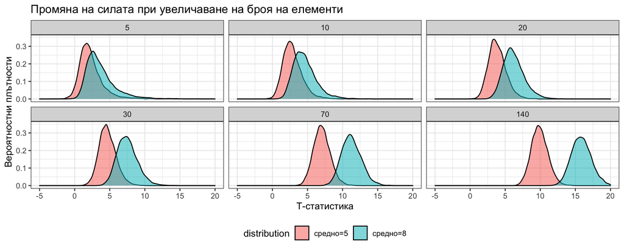

```r
simulate_t <- function (n, m, std = 10) {
  observations <- rnorm(n, m, std)
  mean(observations) / (sd(observations) / sqrt(n))
}

simulate_ht <- function(n, n_sim, mean1, mean2, std = 10) {
  set.seed(1)

  bind_rows(
    data.frame(
      x = replicate(n_sim, simulate_t(n, mean1, std)),
      distribution = paste0("средно=", mean1),
      n = as.factor(n)
    ),
    data.frame(
      x = replicate(n_sim, simulate_t(n, mean2, std)),
      distribution = paste0("средно=", mean2),
      n = as.factor(n)
    )
  )
}

c(5, 10, 20, 30, 70, 140) %>%
  imap(~simulate_ht(.x, 10000, 5, 8, 6)) %>%
  bind_rows() %>%
  ggplot(mapping = aes(x = x, fill = distribution)) +
  geom_density(alpha = 0.55) +
  xlim(c(-5, 20)) +
  facet_wrap(~n) +
  xlab("Т-статистика") +
  ylab("Вероятностни плътности") +
  ggtitle("Промяна на силата при увеличаване на броя на елементи") +
  theme_bw() +
  theme(legend.position = "bottom")
```

[figure not shown]

Забелязваме, че силата на теста $\pi$ расте при увеличаване на броя на наблюденията, но при по-голямо стандартно отклонение, скоростта на растеж на $\pi$ намалява.

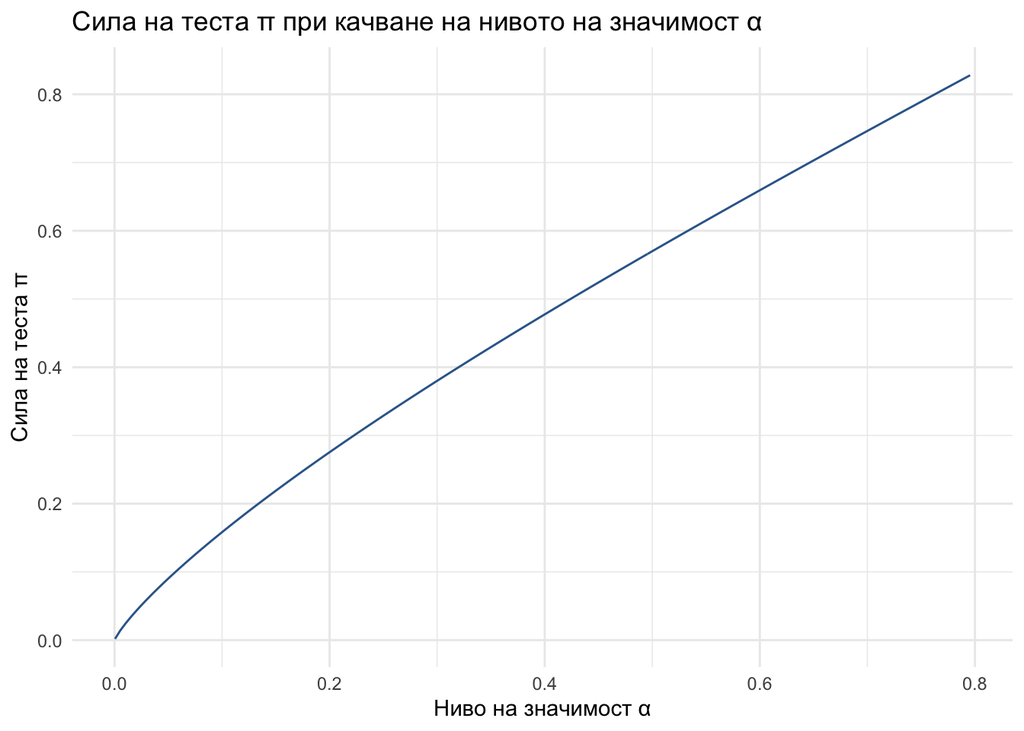

При качване на нивото на значимост $\alpha$, качваме силата на теста ($\pi$) и намаляваме вероятността за грешка от втори род $\beta$, но по този начин увеличаваме вероятността за грешка от първи род $\alpha$.

## Тестване на хипотези върху две извадки

Ако имаме еднакъв брой наблюдения от две случайни величини $X$ и $Y$, които са нормално разпределени с еднакви дисперсии - съответно, $X \sim \mathcal{N}(\mu_1, \sigma^2)$ и $Y \sim \mathcal{N}(\mu_2, \sigma^2)$, можем да зададем нулева хипотеза $H_0 := \mu_1 = \mu_2$. Ако нулевата хипотеза е вярна, то $\bar{X} - \bar{Y} \sim \mathcal{N}(0, \frac{2\sigma^2}{n})$. Тогава

$$Т := \frac{\bar{X}-\bar{Y}}{\sqrt{\frac{S_1^2}{n} + \frac{S_2^2}{n}}} \sim \mathcal{T}(2n - 2)$$

Тогава, можем да използваме досегашния подход при тестване на хипотези за да проверим дали наистина $\mu_1=\mu_2$.

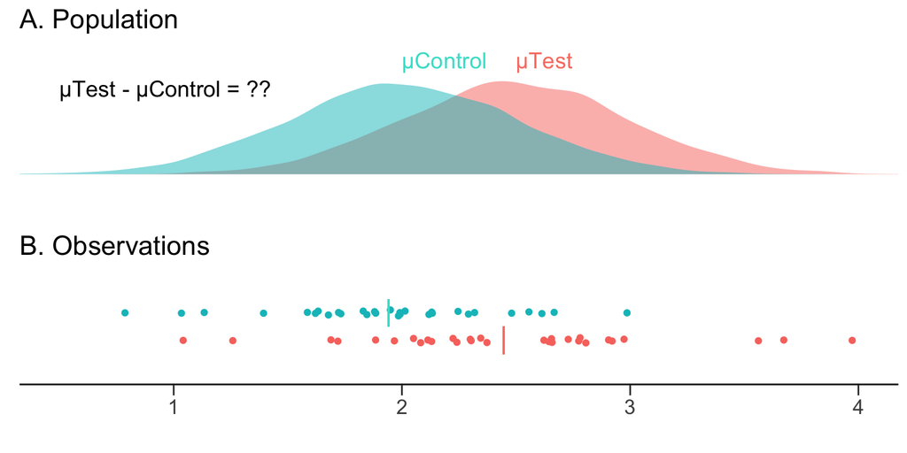

Aко имаме $pvalue < \alpha$, където $\alpha$ е **нивото на значимост**, а **t** e наблюдаваната стойност за **T-статистиката**, можем да отхвърлим нулевата хипотеза, че $\mu_1=\mu_2$.

##### Пример:

```r
# брой елементи в двете случайни извадки
n <- 40

# Симулации на случайни извадки от с.в. X ~ N(3, 9) и Y ~ N(4, 9)
x <- rnorm(n, 3, 3)
y <- rnorm(n, 4, 3)

# Извадкови вариации
v1 <- var(x)
v2 <- var(y)

# Степени на свобода за T-разпределението
degrees_of_freedom <- 2 * n - 2

# Наблюдаваната стойност от T-статистиката
t <- (mean(x) - mean(y)) / sqrt(v1 / 40 + v2 / 40)

# Изчисление за pvalue при двустранен тест
pval <- 2 * min(
  pt(q = t, df = degrees_of_freedom, lower.tail = TRUE),
  pt(q = t, df = degrees_of_freedom, lower.tail = FALSE)
)

# резултат
c("t" = t, "pvalue" = pval, "df" = degrees_of_freedom)
```

```
##           t      pvalue          df
## -1.78387163  0.07833386 78.00000000
```

Или ако просто използваме **t.test**

```r
t.test(x, y, var.equal = TRUE)
```

```
##
##  Two Sample t-test
##
## data:  x and y
## t = -1.7839, df = 78, p-value = 0.07833
## alternative hypothesis: true difference in means is not equal to 0
## 95 percent confidence interval:
##  -2.2952999  0.1258559
## sample estimates:
## mean of x mean of y
##  3.276079  4.360801
```

Когато работим с предположението, че дисперсиите са еднакви, но имаме различен брой наблюдения от двете случайни извадки, за да оценим по-точно общата дисперсия посредством извадъчните дисперсии, използваме формулата за **комбинирана извадъчна дисперсия** и съответно - фoрмулата за **комбинирано стандартно отклонение**.

$$S_p^2 = \frac{(n - 1)S_1^2 + (m - 1)S_2^2}{n + m - 2}$$

където $n$ и $m$ са броят на елементите в двете извадки, а $S_i$ са извадъчните дисперсии на двете извадки. В този случай T-статистиката е

$$Т := \frac{\bar{X}-\bar{Y}}{S_p\sqrt{\frac{1}{n} + \frac{1}{m}}} \sim \mathcal{T}(n + m - 2)$$

##### Пример:

```r
# Формула за смесено извадъчно стандартно отклонение
pooled_sd <- function (x, y) {
  n1 <- length(x)
  n2 <- length(y)
  sqrt(
    ((n1 - 1) * var(x) + (n2 - 1) * var(y))
    /
    (n1 + n2 - 2)
  )
}

# броя на елементите в двете случайни извадки които ще симулираме
n <- 30
m <- 40

# Симулации с различен брой над с.в.
x <- rnorm(n, 3, 2)
y <- rnorm(m, 4, 2)

# Степени на свобода
degrees_of_freedom <- n + m - 2

# Наблюдавана стойност t на Т-статистиката
t <- (mean(x) - mean(y)) / (pooled_sd(x, y) * sqrt((1 / n) + (1 / m)))

# Изчисление за pvalue при двустранен тест
pvalue <- 2 * min(
  pt(t, degrees_of_freedom, lower.tail = TRUE),
  pt(t, degrees_of_freedom, lower.tail = FALSE)
)

# резултат
c("t" = t, "pvalue" = pvalue, "df" = degrees_of_freedom)
```

```
##          t     pvalue         df
## -0.1260876  0.9000346 68.0000000
```

Или с **t.test**

```r
t.test(x, y, var.equal = TRUE)
```

```
##
##  Two Sample t-test
##
## data:  x and y
## t = -0.12609, df = 68, p-value = 0.9
## alternative hypothesis: true difference in means is not equal to 0
## 95 percent confidence interval:
##  -0.9017375  0.7945540
## sample estimates:
## mean of x mean of y
##  3.391455  3.445046
```

Когато работим с предположението, че дисперсиите на двете случайни величини $X$ и $Y$ не са еднакви, тоест $\sigma_X^2 := D(X) \neq D(Y) =: \sigma_Y^2$, за степените на свобода използваме формулата за комбинирани степени на свобода.

$$df_{c} := \frac{(\frac{S_1^2}{n} + \frac{S_2^2}{m})^2}{\frac{(S_1^2/n)^2}{n-1} + \frac{(S_2^2/m)^2}{m-1}}$$

В този случай Т-статистиката ще е
$$Т := \frac{\bar{X}-\bar{Y}}{\sqrt{\frac{S_1^2}{n} + \frac{S_2^2}{n}}} \sim \mathcal{T}(df_{c})$$

##### Пример:

```r
# брой наблюдения над симулираните случайни извадки
n <- 30
m <- 40

# Симулации с различен брой наблюдения над нормално разпределени с.в.
x <- rnorm(n, 3, 2)
y <- rnorm(m, 4, 3)

# Извадъчни дисперсии
v1 <- var(x)
v2 <- var(y)

# Смесени степени на свобода
degrees_of_freedom <- (
  (v1 / n + v2 / m)^2
  /
  ((v1 / n)^2 / (n - 1) + (v2 / m)^2 / (m - 1)))

t <- (mean(x) - mean(y)) / sqrt(v1 / n + v2 / m)

# Изчисление за pvalue при двустранен тест
pvalue <- 2 * min(
  pt(t, degrees_of_freedom, lower.tail = TRUE),
  pt(t, degrees_of_freedom, lower.tail = FALSE)
)

# резултат
c("t" = t, "pvalue" = pvalue, "df" = degrees_of_freedom)
```

```
##          t     pvalue         df
## -1.0872144  0.2808127 67.4390155
```

Или за по-кратко с **t.test**

```r
t.test(x, y, alternative = "two.sided")
```

```
##
##  Welch Two Sample t-test
##
## data:  x and y
## t = -1.0872, df = 67.439, p-value = 0.2808
## alternative hypothesis: true difference in means is not equal to 0
## 95 percent confidence interval:
##  -1.9240875  0.5670285
## sample estimates:
## mean of x mean of y
##  3.474006  4.152536
```

### Сдвоени и несдвоени данни (Paired vs Unpaired)

**Сдвоени данни (наблюдения)** от две извадки наричаме, такива при при които имаме зависимост между извадките и няблюденията идват от едни и същи индивиди, но в различен етап от време. Тоест $x_i$ и $y_i$ са наблюдения върху един и обект. Пример за това би бил ефекта върху нивото на холестерола преди и след приемането на лекарство от едни и същи хора. При **несдвоени данни**, имаме наблюдения от независими извадки $X$ и $Y$. Пример за това би бил, кръвното на група която не приема определено лекарство, и кръвното на група която е приела лекарството. При **t.test** в този случай, при нулева хипотеза $H_0 := \mu_0=0$, тест статистиката $Т$ би била
$$T := \frac{(\bar{X} - \bar{Y})-(\mu_1-\mu_2)}{st.dev(\bar{X}-\bar{Y})} = \frac{\bar{X}_D-\mu_0}{S_D/\sqrt{n}} \sim \mathcal{T}(n - 1)$$
където $\bar{X}_D$ и $S_D$ са извадъчното средно и стандартно отклонение върху разликите между всички наблюдения.

##### Пример:

```r
# Брой елементи от които ще симулираме извадка
n <- 30

# Симулираме наблюдения от с.в.
x <- rnorm(n, 80, 4)
y <- rnorm(n, 84, 4)

# Тест статистика при сдвоен тест
t <- mean(x - y) / (sd(x - y) / sqrt(30))

# Изчисление на pvalue
pvalue <- 2 * min(pt(t, n - 1), pt(t, n - 1, lower.tail = FALSE))

# резултат
c("t" = t, "pvalue" = pvalue, "df" = n - 1)
```

```
##             t        pvalue            df
## -4.760492e+00  4.934324e-05  2.900000e+01
```

Отново, можем да ползваме **t.test**

```r
t.test(x, y, paired = TRUE)
```

```
##
##  Paired t-test
##
## data:  x and y
## t = -4.7605, df = 29, p-value = 4.934e-05
## alternative hypothesis: true difference in means is not equal to 0
## 95 percent confidence interval:
##  -7.352042 -2.933226
## sample estimates:
## mean of the differences
##               -5.142634
```

## Кога ползваме t.test? Тест на Уилкоксън

Т-тестът работи с предположението, че имаме извадки от нормално разпределени случайни величини (популации) и в този случай, трябва да проверим дали нашите данни отговарят на това условие. Поради Централната Гранична Теорема, стига да имаме достатъчно наблюдения (като правило се счита над 30), можем да ползваме Т-тест и без данните ни да следват нормално разпределение, защото

$$\frac{\bar{X} - \mu}{\sigma/\sqrt{n}} \to_d \mathcal{N}(0, 1)$$

Когато тези условия не са спазени, можем да ползваме **Непараметричен тест на Уилкоксън**.

### Тест на Уилкоксън

Тестът на **Уилкоксън** е непараметричен тест, който ни позволява да да сравним две извадки, без да правим преположение за вероятностното разпределение което стои зад тях. Предположенията върху които той стъпва са следните

- Наблюденията са независими едно от друго (**Случайна Извадка**)
- Наблюденията са числени или поне ординални (можем да ги сравним).

При теста на Уилкоксън, работим с нулевата хипотеза $H_0 := P(x_i > y_i) = \frac{1}{2}$, срещу алтернативата $H_1 := P(x_i > y_i) \neq \frac{1}{2}$ и следната $U$-статистика.

Нека имаме $X_1, ...,X_n$ е независима случайна извадка от $X$ и $Y_1, ...,Y_n$ е независима случайна извадка от $Y$ и

$$U := \sum_{i=1}^n\sum_{j=1}^mS(X_i, Y_j)$$

където

$$S(X, Y) := \begin{cases}
1,& \text{if } Y < X\\
1/2, & \text{if } Y = X \\
0, & \text{if } Y > X \\
\end{cases}$$
Разпределението на $U$ е добре известно и го има във всеки справочник. В **R** функцията на разпределението му е **pwilcox**. Виждаме, че $U$ брои броя на инверсиите между Y и Х. Тоест, ако имаме изместеност (Y и X не са с един център), наблюдаваната стойност за $U$-статистиката ще бъде в някаква крайна област на разпределението.

##### Пример:

```r
s <- function(x, y) (y < x) + .5 * (y == x)

x <- c(1, 5, 7,  2, 5,  9, 3, 2, 1, 12)
y <- c(8, 3, 13, 11, 6, 12, 15, 10, 6, 8)

U <- sum(unlist(map(x, ~sum(s(.x, y)))))

c("U" = U, "pvalue" = 2 * pwilcox(U, n = length(x), m = length(y)))
```

```
##           U      pvalue
## 18.00000000  0.01468964
```

Отново, има функция която изпълнява целия тест

```r
# Дава леко по-различни резултати поради вътрешни оптимизации
wilcox.test(x, y)
```

```
##
##  Wilcoxon rank sum test with continuity correction
##
## data:  x and y
## W = 18, p-value = 0.01696
## alternative hypothesis: true location shift is not equal to 0
```

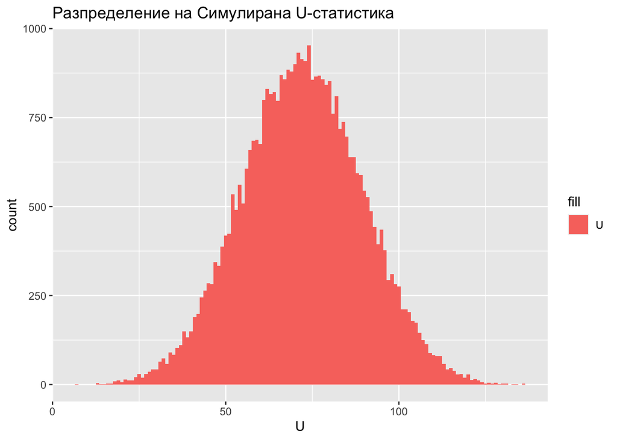

Виждаме, че разпределението прилича на Нормално разпределение при увеличение на броя на наблюдения $n$. При достатъчен брой наблюдения, разпределението на тест статистиката може да се апроксимира с нормално.

**Тестът на Уилкоксън може да бъде изпълнен при всички от горните случаи**

- само върху една извадка - **wilcox.test(x, mu = 10, alternative = “two.sided”)**
- върху две извадки - **wilcox.test(x, y, alternative = “two.sided”)**
- сдвоени данни - **wilcox.test(x, y, alternative = “two.sided”, paired = TRUE)**

## $\chi^2$-тест на Пиърсън

#### Интуиция за две групи

Ако имаме случайна извадка $(Y_1, ..., Y_n)$ от биномно разпределена сл.в. $Y \sim Bin(n, p)$, можем да обозначим броя наблюдавани успехи (елементи от едната група) с $О_S$, а броя наблюдавани неуспехи с $О_F$(елементи от другата група), и съответно техните очаквани стойности с $E_S$ и $E_F$.

| Група I (Успех) | Група II (Неуспех) |
| --- | --- |
| $p$ | $1-p$ |

Тогава, от **ЦГТ**
$$X := \frac{Y-np}{\sqrt{np(1-p)}} \to_d \mathcal{N}(0, 1)$$

Следователно $X^2 \to_d \chi^2(1)$ и ако имаме достатъчно наблюдения $n$, $X^2$ ще има **приблизително** $\chi^2$ разпределение с една степен на свобода.

Oт това, че $\frac{1}{p(1-p)}=\frac{1}{p} + \frac{1}{n-p}$, и това, че $(Y-np)^2=[(n-Y)-n(1-p)]^2$, можем да представим $X^2$ по следния начин
$$X^2 := \frac{(Y-np)^2}{np(1-p)} = \frac{(Y-np)^2}{np}+\frac{(Y-np)^2}{n(1-p)}=\\
= \frac{(Y-np)^2}{np}+\frac{[(n-Y)-n(1-p)]^2}{n(1-p)} =\\
= \frac{(O_S-E_S)^2}{E_S}+\frac{(O_F-E_F)^2}{E_F}$$
По този начин, при $n$ наблюдавани стойности, можем да тестваме нулева хипотеза, че очакваният брой успехи (елементи от едната група) $E_S = np_S$ е определено число, а очаквания брой неуспехи ( елементи от другата група) $E_F =np_F$е друго число. Също, можем да тестваме и хипотези за самите вероятности на двете групи $p_S$ и $p_F$. Ако нулевата хипотеза не е вярна, наблюдаваната $X^2$ статистика ще е прекалено надясно от $0$.

Както при биномно разпределена случайна величина, така и при такава с много групи (**мултиномно** разпределена), съществува асимптотична апроксимация с нормално разпределение. В такъв случай, можем да направим сходни разсъждения за $k$ на брой различни групи и
$$X^2 := \sum_{i=1}^k\frac{(O_i-E_i)^2}{E_i}$$

ще има, отново асимптотично приблизително $\chi^2$ разпределение, но този път с $k-1$ степени на свобода, където $О_i$ $E_i$ са наблюдавания и очаквания под $H_0$ брой елементи от $i$-тата група.

|  | Група 1 | Група 2 | … | Група k |
| --- | --- | --- | --- | --- |
| Наблюдавани | $O_1 := n\hat{p_1}$ | $O_2 := n\hat{p_2}$ | … | $O_k := n\hat{p_k}$ |
| Очаквани под $H_0$ | $E_1 := np_1$ | $E_2 := np_2$ | … | $E_k := np_k$ |

Нека симулираме разпределенията на $X^2$ при вярна нулева хипотеза и различен брой групи, с цел да видим, че наистина имат $\chi^2$ разпределения.

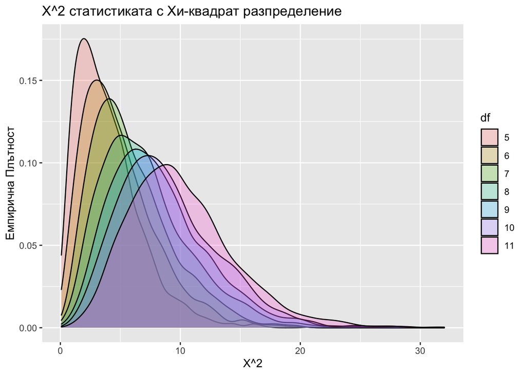

```r
simulate_chsq <- function(n = 60, th_probs, hyp_probs) {
  k = length(hyp_probs)
  # Правим извадка от к на брой групи с теоретични вероятности за всяка - th_probs
  x <- sample(1:k, prob = th_probs, size = n, replace = TRUE)

  # изграждаме брой елементи във всяка група
  observed <- unlist(map(1:k, ~sum(x == .x)))
  # очакваните бройки елементи ако нулевата хипотеза е вярна
  expected <- n * hyp_probs

  # връщаме X^2 статистиката
  sum((observed - expected)^2 / expected)
}

# общ брой елементи от всички групи
n <- 120
# Брой симулации на X^2-статистиката
s <- 2000

# за степени на свобода от 4 до 10 генерираме X^2 статистики
5:11 %>%
  imap(
    ~data.frame(
      # Задаваме истинските вероятности за нулева хипотеза, така че да видим разпределенията
      x = replicate(s, simulate_chsq(n, th_probs = rep(1 / .x, .x), hyp_probs = rep(1 / .x, .x))),
      df = as.factor(.x)
    )
  ) %>%
  # сливаме всички data.frames в един data.frame с цел да визуализираме по-лесно
  bind_rows() %>%
  ggplot(mapping = aes(x = x, fill = df)) +
  geom_density(alpha = 0.25) +
  ggtitle("X^2 статистиката с Хи-квадрат разпределение") +
  xlab("X^2") +
  ylab("Емпирична Плътност")
```

Нека направим тест с четири групи симулирани с теоретични вероятности 1/4 за всяка и $n=60$. Тогава, ако тестваме нулевата хипотеза $H_0 := \{p_1=1/2, p_2 = p_3=p_4=1/6\}$, нашата $X^2$ статистика би трябвало да е прекалено надясно от нулата.

```r
xsquared <- simulate_chsq(n = 60, th_probs = rep(1 / 4, 4), hyp_probs = c(1/2, 1/6, 1/6, 1/6))

pvalue <- pchisq(xsquared, df = 3, lower.tail = FALSE)

c("X^2" = xsquared, "pvalue" = pvalue, "df" = 3)
```

```
##          X^2       pvalue           df
## 1.793333e+01 4.539965e-04 3.000000e+00
```

|  | Група 1 | Група 2 | Група 3 | Група 4 |
| --- | --- | --- | --- | --- |
| Истински Очаквания | 15 | 15 | 15 | 15 |
| $O_i := n\hat{p_i}$ := Наблюдавани | 14 | 13 | 17 | 16 |
| $E_i := np_i$ := Очаквани под $H_0$ | 30 | 10 | 10 | 10 |
| $\frac{(O_i-E_i)^2}{E_i}$ | $\frac{(14-30)^2}{30}=8.53$ | $\frac{(13-10)^2}{10}=0.90$ | $\frac{(17-10)^2}{10}=4.90$ | $\frac{(16-10)^2}{10}=3.60$ |

Виждаме, че вероятността да наблюдаваме стойност по-голяма или равна от $17.93$ на $X^2$-статистиката е много малка ($pvalue := P(X^2\ge17.93 < 0.005$). В такъв случай, можем да отхвълим нулевата хипотеза, че очакваните вероятности са $\{p_1=1/2, p_2 = p_3=p_4=1/6\}$.

Критичните области и техните pvalue-та биха изглеждали така

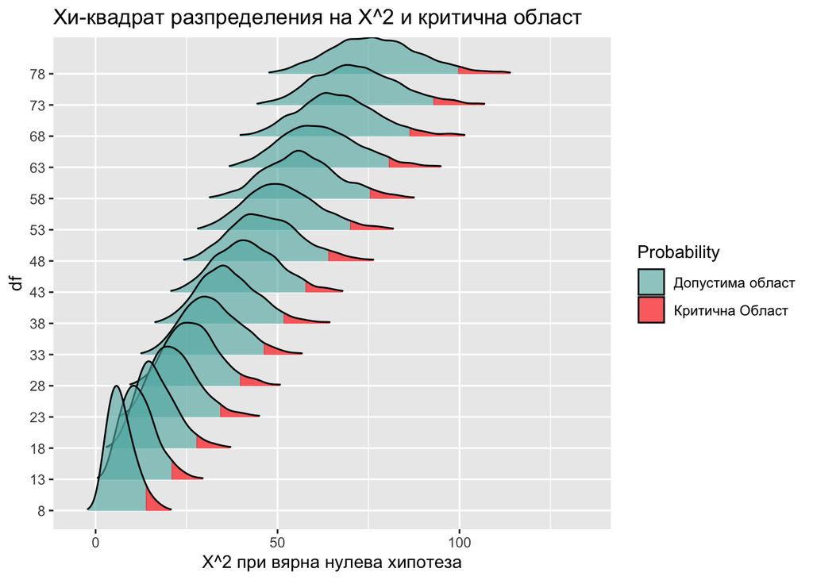

В **R** за улеснение, използваме функцията **chisq.test(x, p)** където **x** ще е наблюдаван брой елементи в различните групи, а **p** е вероятностите под нулевата хипотеза, за различните групи.

## Приложения на $\chi^2$-тест

### Проверка за произволно дискретно разпределение

Ако имаме дискретни данни, бихме могли да тестваме хипотезата, че наблюдаваната извадка идва от дискретна случайна величина с избрано от нас разпределение.

#### Пример

Нека имаме случайна извадка $X_1, ..., X_{100} \sim^d X \sim Poi(2)$. Искаме да тестваме хипотезата $H_0 := \lambda = 2.5$ срещу алтернативата $H_1 := \lambda \neq 2.5$

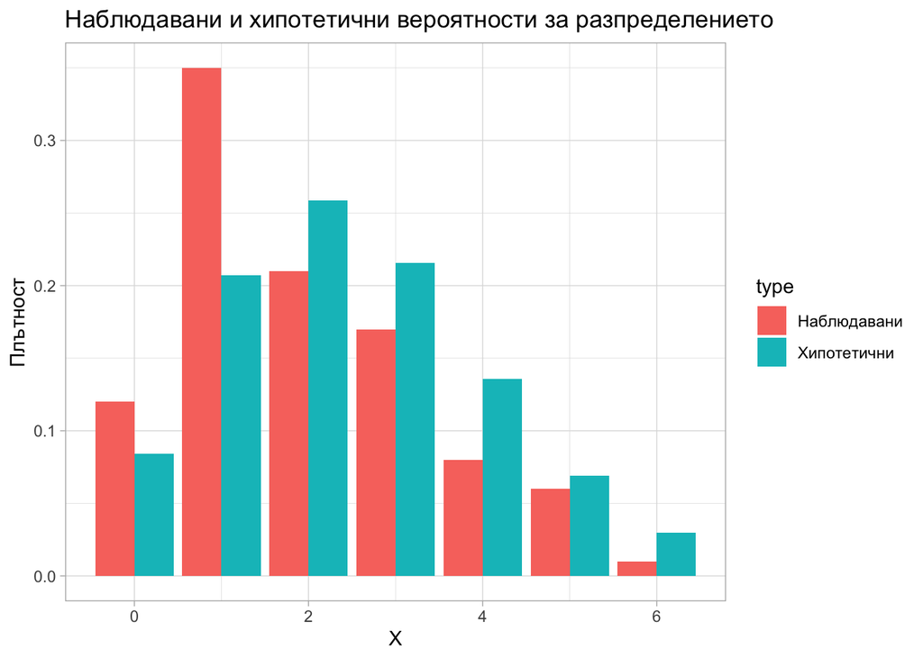

```r
# брой наблюдения които имаме
n <- 100

set.seed(2)
# Стойностите които примерно сме наблюдавали
observed_props <- rpois(n, lambda = 2) %>%
  table() %>%
  prop.table() %>%
  unname() %>%
  as.vector()

# Хипотетични вероятности под нулева хипотеза
hypothet_props <- dpois(0:6, lambda = 2.5)
# Калибрация с цел по-лесно тестване
hypothet_props <- hypothet_props + (1 - sum(hypothet_props)) / 7

df <- bind_rows(
  data.frame(x = 0:6, y = hypothet_props, type = "Хипотетични"),
  data.frame(x = 0:6, y = observed_props, type = "Наблюдавани")
)

df %>%
  ggplot(mapping = aes(x = x, y = y, fill = type)) +
  geom_bar(position = "dodge", stat = "identity") +
  ggtitle("Наблюдавани и хипотетични вероятности за разпределението") +
  xlab("X") +
  ylab("Плътност") +
  theme_light()
```

Така, ако нулевата хипотеза е вярна,

$$X^2 := \sum_{i=0}^6\frac{(n\hat{p_i}-np_i)^2}{np_i} \sim \chi^2_{6}$$

```r
xsq <- sum((n * observed_props - n * hypothet_props)^2 / (n * hypothet_props))
round(pchisq(xsq, lower.tail = FALSE, df = 6), 6)
```

```
## [1] 0.009415
```

Така виждаме, че е много малко вероятно да наблюдаваме съответната тестова статистика, ако истинското разпоределение беше $Poi(2.5)$. В такъв случай, бихме могли да отхвърлим нулевата хипотеза при избрано от нас ниво на съгласие $\alpha$.

В **R** за по-лесно това би станало така

```r
chisq.test(n * observed_props, p = hypothet_props)
```

```
##
##  Chi-squared test for given probabilities
##
## data:  n * observed_props
## X-squared = 16.964, df = 6, p-value = 0.009415
```

### Проверка за произволно непрекъснато разпределение

Ако имаме непрекъснати данни и искаме да тестваме хипотезата, че те идват от случайна величина с дадено непрекъснато разпределение, бихме могли да дискретизираме данните в под интервали и да проверим дали честотата с която се падат е същата като при същата дискретизация на плътността на тестваното от нас разпределение.

#### Пример

Нека имаме $2000$ на брой наблюдения $X_1, ..., X_{2000}$ от случайна величина $X \sim \Gamma(12, 4)$ и нека тестваме нулева хипотеза с истинските параметри $\alpha = 12, \beta = 4$. В този случай, не би трябвало да можем да отхвърлим нулевата хипотеза.

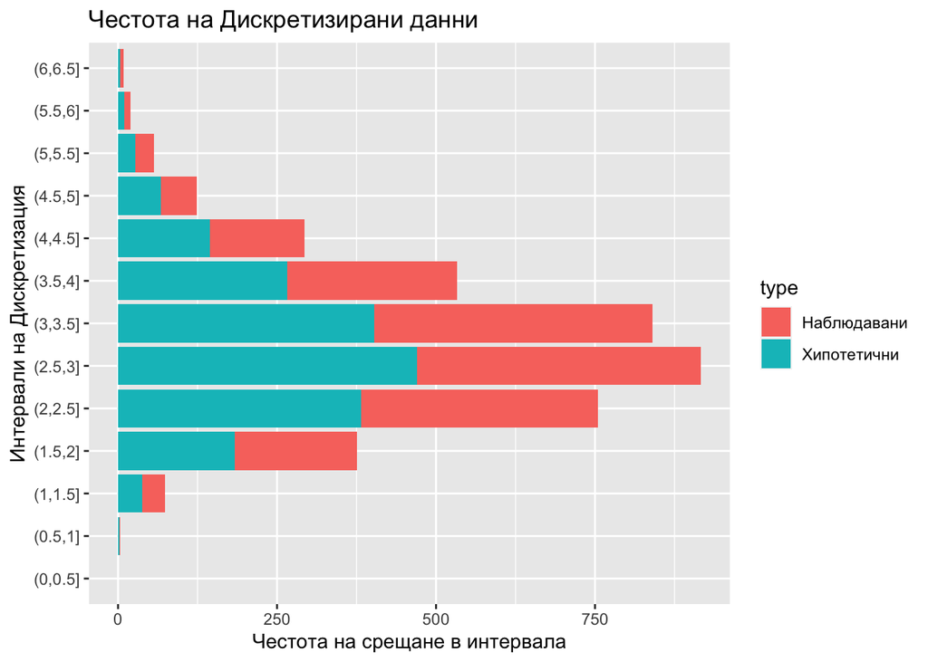

```r
# Брой наблюдения
n <- 2000

# Параметри под нулевата хипотеза за разпределението
hyp_shape <- 12; hyp_rate <- 4;

# seed с цел възпроизвеждане на резултатите
set.seed(16)

# Симулирани данни от Гама разпределена случайна величина
x <- rgamma(n, 12, 4)

# Дискретизация
divisions <- seq(0.5, 6.5, by = 0.5)

# Хипотетични честоти ако нулевата хипотеза е вярна
hyp_props <- pgamma(divisions, hyp_shape, hyp_rate) - pgamma(divisions - 0.5, hyp_shape, hyp_rate)

# таблица с брой наблюдения в интервалите
observed_table <- x %>%
  cut(c(0, divisions)) %>%
  table()

# Наблюдавани честоти
observed <- as.vector(unname(observed_table))

# Визуализация на честотите (подобно е на хистограма)
bind_rows(
  data.frame(x = names(observed_table), y = observed, type = "Наблюдавани"),
  data.frame(x = names(observed_table), y = n * hyp_props, type = "Хипотетични"),
) %>%
  ggplot(mapping = aes(x = x, y = y, fill = type)) +
  geom_bar(position = "stack", stat = "identity") +
  coord_flip() +
  xlab("Интервали на Дискретизация") +
  ylab("Честота на срещане в интервала") +
  ggtitle("Честота на Дискретизирани данни")
```

```r
# добавяме остатъка за да се сумират до 1
hyp_props <- hyp_props + (1 - sum(hyp_props)) / length(hyp_props)

# изпълнение на теста
chisq.test(observed, p = hyp_props)
```

```
##
##  Chi-squared test for given probabilities
##
## data:  observed
## X-squared = 7.6662, df = 12, p-value = 0.8106
```

Не успяваме да отхвърлим нулевата хипотеза, че данните наблюдения от случайна величина $X \sim \Gamma (12, 4)$.

### Проверка за независимост на две случайни величини

Ако имаме две случайни извадки $X_1, ..., X_n \sim^d X$ и $Y_1, ..., Y_n \sim^d Y$, бихме могли отново да изградим таблици с пропорции $\hat{p}_{ij} := P(X = i, Y = j)$ и съответно маргиналните пропорции $\hat{p}_{i, \forall}:= P(X=i)=\sum_{j = 1}^c\hat{p}_{ij}$ и $\hat{p}_{\forall, j}:= P(Y=j)=\sum_{i = 1}^r\hat{p}_{ij}$, където $r$ и $c$ са бройките уникални елементи съответно за $X$ и $Y$.

В такъв случай, ако случайните величини $X$ и $Y$ са независими, то $P(X = x_i, Y = y_j) = P(X = x_i)\cdot P(Y=y_j) := p_{i, \forall}p_{\forall,j}$ за всяко $i, j$ и би трябвало да наблюдаваме емпирични вероятности които приблизително притежават това свойство.

Тогава

$$X^2 := \sum_{i=1}^r\sum_{j=1}^c \frac{(O_{i,j}-E_{i,j})^2}{E_{i,j}} \sim \chi^2_{(r-1)(c-1)}$$

#### Пример

Нека симулираме две извадки с големина $n=600$ от независими случайни величини $X \sim Bin(8, 0.5), Y \sim Poi(2.3)$ и изпълним $\chi^2$-тест за независимост, като евентуално след това, бихме могли да добавим зависимост между част от наблюденията с цел да видим как се променят резултатите от $\chi^2$ теста.

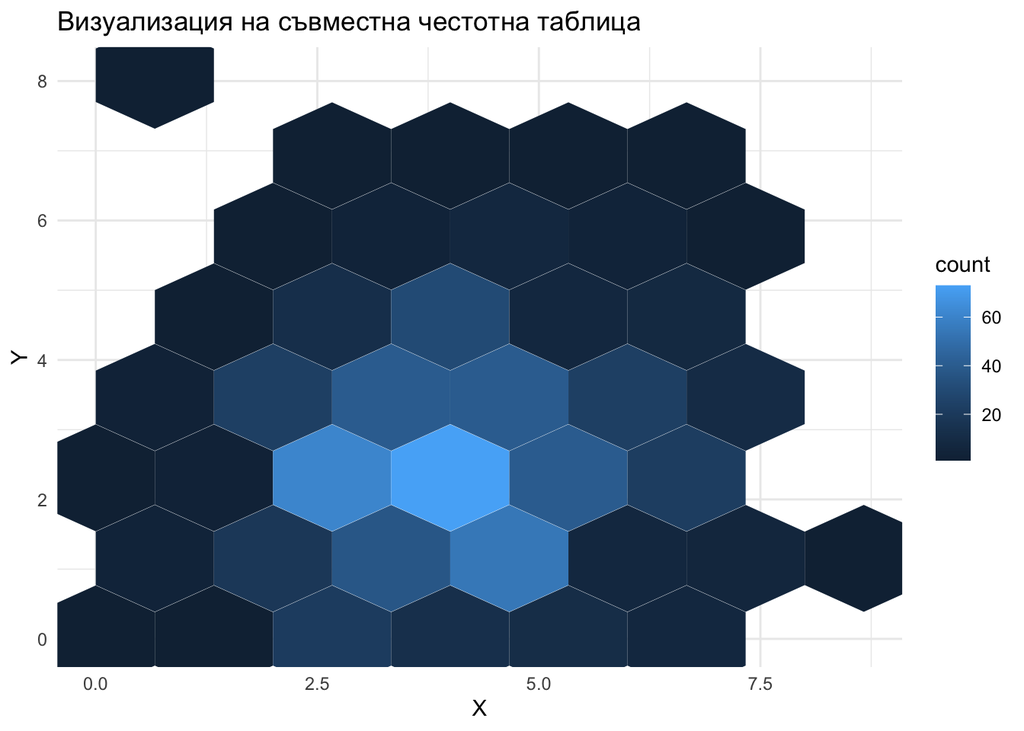

```r
# генериране на две независими случайни величини
x <- rbinom(600, size = 8, prob = 1 / 2)
y <- rpois(600, 2.3)

# Вкарване на зависимост
# y[510:600] <- y[510:600] + x[510:600]

# таблица брояща наблюдавани комбинации от вида (X, Y)
observed <- table(x, y)

# брой на всички елементи
N <- sum(observed)

# Маргинални емпирични вероятности
x_marginal <- prop.table(table(x))
y_marginal <- prop.table(table(y))

# Очаквани пропорции
expected_proportions <- x_marginal %*% t(y_marginal)

# Очаквани бройки при предположение за независимост
expected <- N * expected_proportions

# X^2 статистика
xsquare <- sum((observed - expected)^2 / expected)

# Степени на свобода
degrees_of_freedom <- prod(dim(observed) - 1)

# pvalue за съответната Х^2 статистика
pvalue <- pchisq(xsquare, df = degrees_of_freedom, lower.tail = FALSE)
c("X^2" = xsquare, "df" = degrees_of_freedom, "pvalue" = pvalue)
```

```
##        X^2         df     pvalue
## 55.0295335 72.0000000  0.9314768
```

Или с за кратко с функцията **chisq.test**

```r
chisq.test(observed)
```

```
##
##  Pearson's Chi-squared test
##
## data:  observed
## X-squared = 55.03, df = 72, p-value = 0.9315
```

Функцията **chisq.test** автоматично разбира, че става въпрос за тест за независимост когато ѝ се подаде таблица.